# Build a plot layer by layer

## Introduction

One of the key ideas behind ggplot2 is that it allows you to easily iterate, building up a complex plot a layer at a time. Each layer can come from a different dataset and have a different aesthetic mapping, making it possible to create sophisticated plots that display data from multiple sources.

You’ve already created layers with functions like `geom_point()` and `geom_histogram()`. In this chapter, you’ll dive into the details of a layer, and how you can control all five components: data, the aesthetic mappings, the geom, stat, and position adjustments. The goal here is to give you the tools to build sophisticated plots tailored to the problem at hand.

## Building a plot

So far, whenever we’ve created a plot with `ggplot()`, we’ve immediately added on a layer with a geom function. But it’s important to realise that there really are two distinct steps. First we create a plot with default dataset and aesthetic mappings:

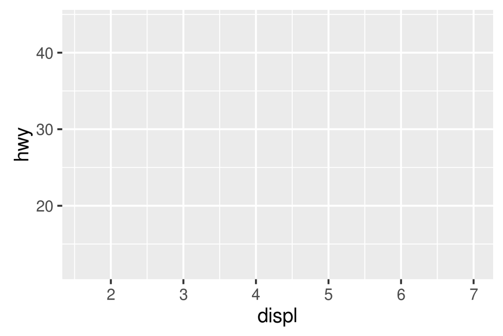

```r
p <- ggplot(mpg, aes(displ, hwy))
p
```

There’s nothing to see yet, so we need to add a layer:

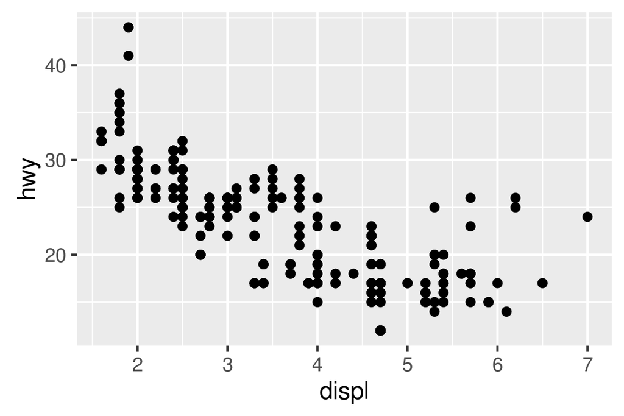

```r
p + geom_point()
```

`geom_point()` is a shortcut. Behind the scenes it calls the `layer()` function to create a new layer:

```r
p + layer(
  mapping = NULL,
  data = NULL,
  geom = "point",
  stat = "identity",
  position = "identity"
)
```

This call fully specifies the five components to the layer:

- **mapping**: A set of aesthetic mappings, specified using the `aes()` function and combined with the plot defaults as described in aesthetic mappings. If `NULL`, uses the default mapping set in `ggplot()`.
- **data**: A dataset which overrides the default plot dataset. It is usually omitted (set to `NULL`), in which case the layer will use the default data specified in `ggplot()`. The requirements for data are explained in more detail in data.
- **geom**: The name of the geometric object to use to draw each observation. Geoms are discussed in more detail in geom, and the toolbox explores their use in more depth.

  Geoms can have additional arguments. All geoms take aesthetics as parameters. If you supply an aesthetic (e.g. colour) as a parameter, it will not be scaled, allowing you to control the appearance of the plot, as described in setting vs. mapping. You can pass params in `...` (in which case stat and geom parameters are automatically teased apart), or in a list passed to `geom_params`.
- **stat**: The name of the statistical tranformation to use. A statistical transformation performs some useful statistical summary, and is key to histograms and smoothers. To keep the data as is, use the “identity” stat. Learn more in statistical transformations.

  You only need to set one of stat and geom: every geom has a default stat, and every stat a default geom.

  Most stats take additional parameters to specify the details of statistical transformation. You can supply params either in `...` (in which case stat and geom parameters are automatically teased apart), or in a list called `stat_params`.
- **position**: The method used to adjust overlapping objects, like jittering, stacking or dodging. More details in position.

It’s useful to understand the `layer()` function so you have a better mental model of the layer object. But you’ll rarely use the full `layer()` call because it’s so verbose. Instead, you’ll use the shortcut `geom_` functions: `geom_point(mapping, data, ...)` is exactly equivalent to `layer(mapping, data, geom = "point", ...)`.

## Data

Every layer must have some data associated with it, and that data must be in a tidy data frame. You’ll learn about tidy data in tidy data, but for now, all you need to know is that a tidy data frame has variables in the columns and observations in the rows. This is a strong restriction, but there are good reasons for it:

- Your data is very important, so it’s best to be explicit about it.
- A single data frame is also easier to save than a multitude of vectors, which means it’s easier to reproduce your results or send your data to someone else.
- It enforces a clean separation of concerns: ggplot2 turns data frames into visualisations. Other packages can make data frames in the right format (learn more about that in model visualisation).

The data on each layer doesn’t need to be the same, and it’s often useful to combine multiple datasets in a single plot. To illustrate that idea I’m going to generate two new datasets related to the mpg dataset. First I’ll fit a loess model and generate predictions from it. (This is what `geom_smooth()` does behind the scenes)

```r
mod <- loess(hwy ~ displ, data = mpg)
grid <- data_frame(displ = seq(min(mpg$displ), max(mpg$displ), length = 50))
grid$hwy <- predict(mod, newdata = grid)

grid
```

```
#> # A tibble: 50 × 2
#>   displ   hwy
#>   <dbl> <dbl>
#> 1  1.60  33.1
#> 2  1.71  32.2
#> 3  1.82  31.3
#> 4  1.93  30.4
#> 5  2.04  29.6
#> 6  2.15  28.8
#> # ... with 44 more rows
```

Next, I’ll isolate observations that are particularly far away from their predicted values:

```r
std_resid <- resid(mod) / mod$s
outlier <- filter(mpg, abs(std_resid) > 2)
outlier
```

```
#> # A tibble: 6 × 11
#>   manufacturer      model displ  year   cyl      trans   drv   cty   hwy
#>          <chr>      <chr> <dbl> <int> <int>      <chr> <chr> <int> <int>
#> 1    chevrolet   corvette   5.7  1999     8 manual(m6)     r    16    26
#> 2      pontiac grand prix   3.8  2008     6   auto(l4)     f    18    28
#> 3      pontiac grand prix   5.3  2008     8   auto(s4)     f    16    25
#> 4   volkswagen      jetta   1.9  1999     4 manual(m5)     f    33    44
#> 5   volkswagen new beetle   1.9  1999     4 manual(m5)     f    35    44
#> 6   volkswagen new beetle   1.9  1999     4   auto(l4)     f    29    41
#> # ... with 2 more variables: fl <chr>, class <chr>
```

I’ve generated these datasets because it’s common to enhance the display of raw data with a statistical summary and some annotations. With these new datasets, I can improve our initial scatterplot by overlaying a smoothed line, and labelling the outlying points:

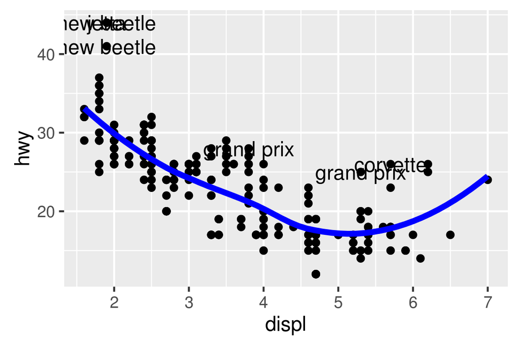

```r
ggplot(mpg, aes(displ, hwy)) +
  geom_point() +
  geom_line(data = grid, colour = "blue", size = 1.5) +
  geom_text(data = outlier, aes(label = model))
```

(The labels aren’t particularly easy to read, but you can fix that with some manual tweaking.)

Note that you need the explicit `data =` in the layers, but not in the call to `ggplot()`. That’s because the argument order is different. This is a little inconsistent, but it reduces typing for the common case where you specify the data once in `ggplot()` and modify aesthetics in each layer.

In this example, every layer uses a different dataset. We could define the same plot in another way, omitting the default dataset, and specifying a dataset for each layer:

```r
ggplot(mapping = aes(displ, hwy)) +
  geom_point(data = mpg) +
  geom_line(data = grid) +
  geom_text(data = outlier, aes(label = model))
```

I don’t particularly like this style in this example because it makes it less clear what the primary dataset is (and because of the way that the arguments to `ggplot()` are ordered, it actually requires more keystrokes). However, you may prefer it in cases where there isn’t a clear primary dataset, or where the aesthetics also vary from layer to layer.

### Exercises

1. The first two arguments to ggplot are `data` and `mapping`. The first two arguments to all layer functions are `mapping` and `data`. Why does the order of the arguments differ? (Hint: think about what you set most commonly.)
2. The following code uses dplyr to generate some summary statistics about each class of car (you’ll learn how it works in data transformation).

   ```r
   library(dplyr)
   class <- mpg %>%
     group_by(class) %>%
     summarise(n = n(), hwy = mean(hwy))
   ```

   Use the data to recreate this plot:

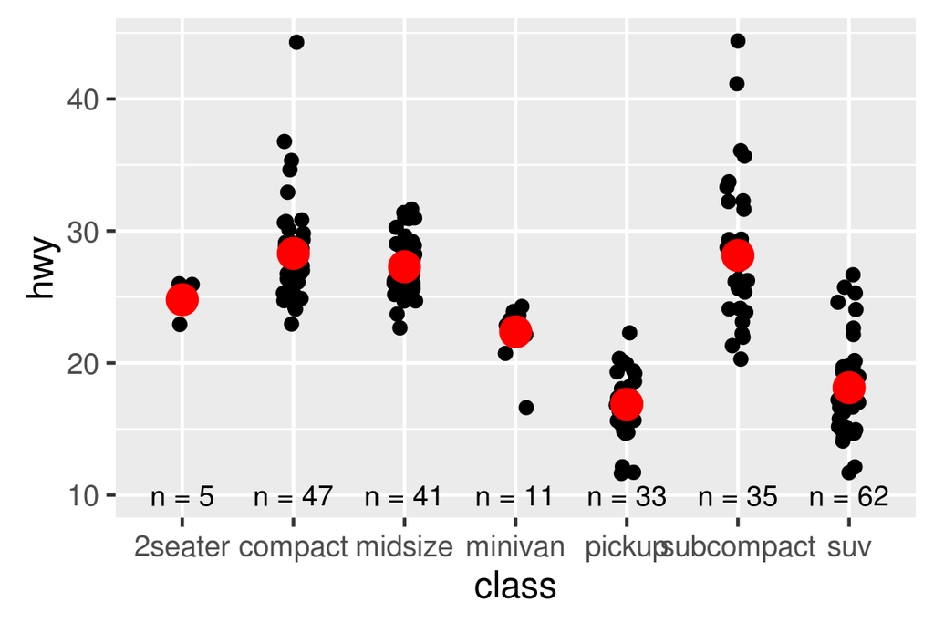

## Aesthetic mappings

The aesthetic mappings, defined with `aes()`, describe how variables are mapped to visual properties or **aesthetics**. `aes()` takes a sequence of aesthetic-variable pairs like this:

```r
aes(x = displ, y = hwy, colour = class)
```

(If you’re American, you can use *color*, and behind the scenes ggplot2 will correct your spelling ;)

Here we map x-position to `displ`, y-position to `hwy`, and colour to `class`. The names for the first two arguments can be omitted, in which case they correspond to the x and y variables. That makes this specification equivalent to the one above:

```r
aes(displ, hwy, colour = class)
```

While you can do data manipulation in `aes()`, e.g. `aes(log(carat), log(price))`, it’s best to only do simple calculations. It’s better to move complex transformations out of the `aes()` call and into an explicit `dplyr::mutate()` call, as you’ll learn about in mutate. This makes it easier to check your work and it’s often faster because you need only do the transformation once, not every time the plot is drawn.

Never refer to a variable with `$` (e.g., `diamonds$carat`) in `aes()`. This breaks containment, so that the plot no longer contains everything it needs, and causes problems if ggplot2 changes the order of the rows, as it does when facetting.

### Specifying the aesthetics in the plot vs. in the layers

Aesthetic mappings can be supplied in the initial `ggplot()` call, in individual layers, or in some combination of both. All of these calls create the same plot specification:

```r
ggplot(mpg, aes(displ, hwy, colour = class)) +
  geom_point()
ggplot(mpg, aes(displ, hwy)) +
  geom_point(aes(colour = class))
ggplot(mpg, aes(displ)) +
  geom_point(aes(y = hwy, colour = class))
ggplot(mpg) +
  geom_point(aes(displ, hwy, colour = class))
```

Within each layer, you can add, override, or remove mappings:

| Operation | Layer aesthetics | Result |
| --- | --- | --- |
| Add | `aes(colour = cyl)` | `aes(mpg, wt, colour = cyl)` |
| Override | `aes(y = disp)` | `aes(mpg, disp)` |
| Remove | `aes(y = NULL)` | `aes(mpg)` |

If you only have one layer in the plot, the way you specify aesthetics doesn’t make any difference. However, the distinction is important when you start adding additional layers. These two plots are both valid and interesting, but focus on quite different aspects of the data:

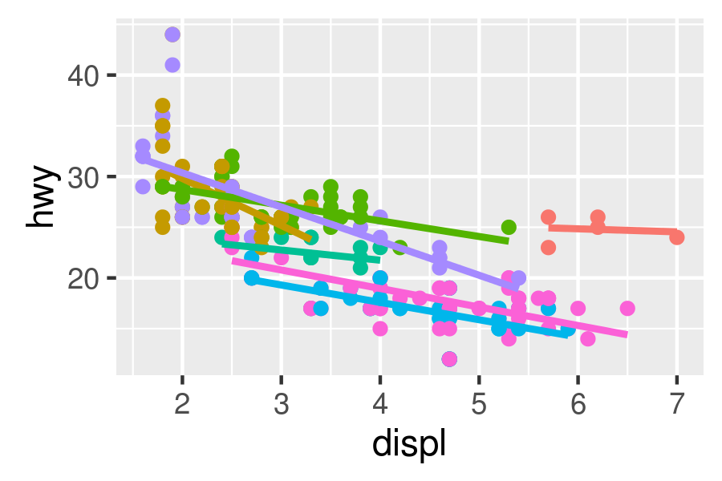

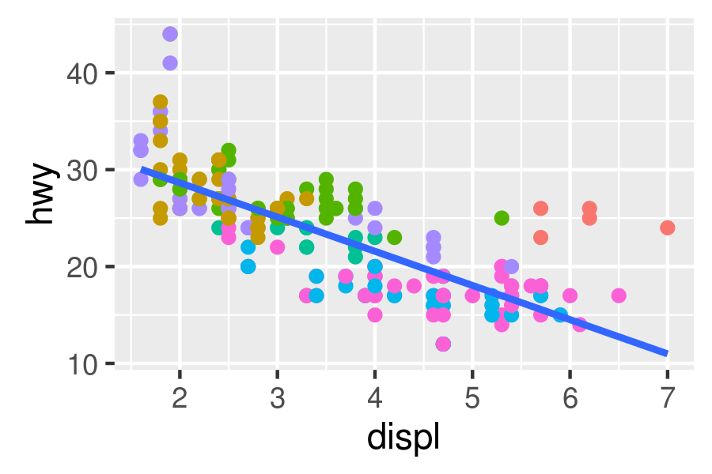

```r
ggplot(mpg, aes(displ, hwy, colour = class)) +
  geom_point() +
  geom_smooth(method = "lm", se = FALSE) +
  theme(legend.position = "none")

ggplot(mpg, aes(displ, hwy)) +
  geom_point(aes(colour = class)) +
  geom_smooth(method = "lm", se = FALSE) +
  theme(legend.position = "none")
```

Generally, you want to set up the mappings to illuminate the structure underlying the graphic and minimise typing. It may take some time before the best approach is immediately obvious, so if you’ve iterated your way to a complex graphic, it may be worthwhile to rewrite it to make the structure more clear.

### Setting vs. mapping

Instead of mapping an aesthetic property to a variable, you can set it to a *single* value by specifying it in the layer parameters. We **map** an aesthetic to a variable (e.g., `aes(colour = cut)`) or **set** it to a constant (e.g., `colour = "red"`). If you want appearance to be governed by a variable, put the specification inside `aes()`; if you want override the default size or colour, put the value outside of `aes()`.

The following plots are created with similar code, but have rather different outputs. The second plot **maps** (not sets) the colour to the value ‘darkblue’. This effectively creates a new variable containing only the value ‘darkblue’ and then scales it with a colour scale. Because this value is discrete, the default colour scale uses evenly spaced colours on the colour wheel, and since there is only one value this colour is pinkish.

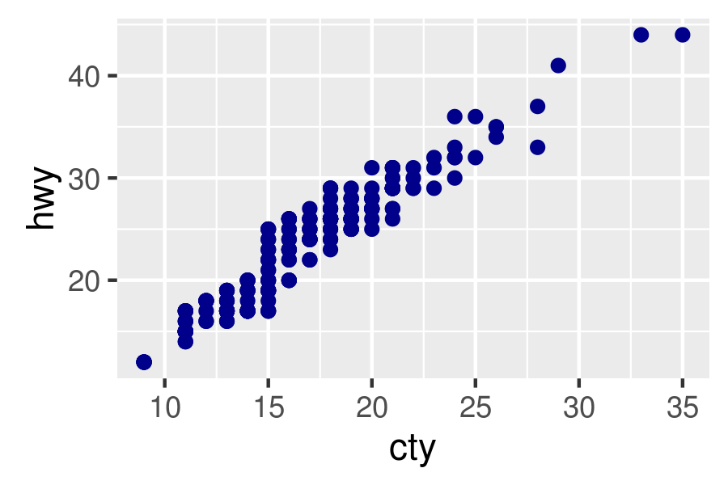

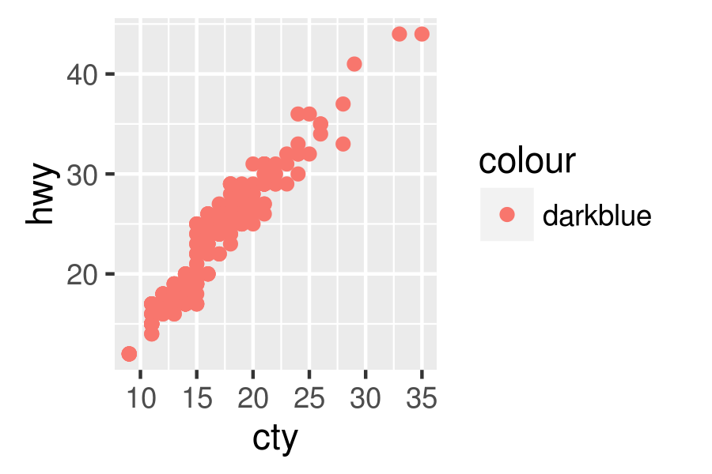

```r
ggplot(mpg, aes(cty, hwy)) +
  geom_point(colour = "darkblue")

ggplot(mpg, aes(cty, hwy)) +
  geom_point(aes(colour = "darkblue"))
```

A third approach is to map the value, but override the default scale:

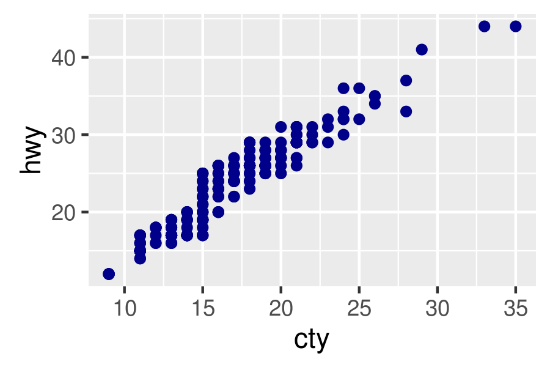

```r
ggplot(mpg, aes(cty, hwy)) +
  geom_point(aes(colour = "darkblue")) +
  scale_colour_identity()
```

This is most useful if you always have a column that already contains colours. You’ll learn more about that in the identity scale.

It’s sometimes useful to map aesthetics to constants. For example, if you want to display multiple layers with varying parameters, you can “name” each layer:

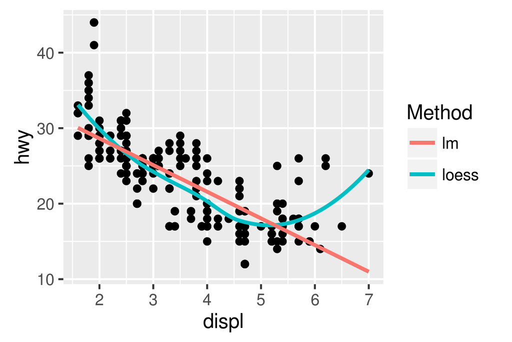

```r
ggplot(mpg, aes(displ, hwy)) +
  geom_point() +
  geom_smooth(aes(colour = "loess"), method = "loess", se = FALSE) +
  geom_smooth(aes(colour = "lm"), method = "lm", se = FALSE) +
  labs(colour = "Method")
```

### Exercises

1. Simplify the following plot specifications:

   ```r
   ggplot(mpg) +
     geom_point(aes(mpg$disp, mpg$hwy))

   ggplot() +
    geom_point(mapping = aes(y = hwy, x = cty), data = mpg) +
    geom_smooth(data = mpg, mapping = aes(cty, hwy))

   ggplot(diamonds, aes(carat, price)) +
     geom_point(aes(log(brainwt), log(bodywt)), data = msleep)
   ```

2. What does the following code do? Does it work? Does it make sense? Why/why not?

   ```r
   ggplot(mpg) +
     geom_point(aes(class, cty)) +
     geom_boxplot(aes(trans, hwy))
   ```

3. What happens if you try to use a continuous variable on the x axis in one layer, and a categorical variable in another layer? What happens if you do it in the opposite order?

## Geoms

Geometric objects, or **geoms** for short, perform the actual rendering of the layer, controlling the type of plot that you create. For example, using a point geom will create a scatterplot, while using a line geom will create a line plot.

- Graphical primitives:
  - `geom_blank()`: display nothing. Most useful for adjusting axes limits using data.
  - `geom_point()`: points.
  - `geom_path()`: paths.
  - `geom_ribbon()`: ribbons, a path with vertical thickness.
  - `geom_segment()`: a line segment, specified by start and end position.
  - `geom_rect()`: rectangles.
  - `geom_polyon()`: filled polygons.
  - `geom_text()`: text.
- One variable:
  - Discrete:
    - `geom_bar()`: display distribution of discrete variable.
  - Continuous
    - `geom_histogram()`: bin and count continuous variable, display with bars.
    - `geom_density()`: smoothed density estimate.
    - `geom_dotplot()`: stack individual points into a dot plot.
    - `geom_freqpoly()`: bin and count continuous variable, display with lines.
- Two variables:
  - Both continuous:
    - `geom_point()`: scatterplot.
    - `geom_quantile()`: smoothed quantile regression.
    - `geom_rug()`: marginal rug plots.
    - `geom_smooth()`: smoothed line of best fit.
    - `geom_text()`: text labels.
  - Show distribution:
    - `geom_bin2d()`: bin into rectangles and count.
    - `geom_density2d()`: smoothed 2d density estimate.
    - `geom_hex()`: bin into hexagons and count.
  - At least one discrete:
    - `geom_count()`: count number of point at distinct locations
    - `geom_jitter()`: randomly jitter overlapping points.
  - One continuous, one discrete:
    - `geom_bar(stat = "identity")`: a bar chart of precomputed summaries.
    - `geom_boxplot()`: boxplots.
    - `geom_violin()`: show density of values in each group.
  - One time, one continuous
    - `geom_area()`: area plot.
    - `geom_line()`: line plot.
    - `geom_step()`: step plot.
  - Display uncertainty:
    - `geom_crossbar()`: vertical bar with center.
    - `geom_errorbar()`: error bars.
    - `geom_linerange()`: vertical line.
    - `geom_pointrange()`: vertical line with center.
  - Spatial
    - `geom_map()`: fast version of `geom_polygon()` for map data.
- Three variables:
  - `geom_contour()`: contours.
  - `geom_tile()`: tile the plane with rectangles.
  - `geom_raster()`: fast version of `geom_tile()` for equal sized tiles.

Each geom has a set of aesthetics that it understands, some of which *must* be provided. For example, the point geoms requires x and y position, and understands colour, size and shape aesthetics. A bar requires height (`ymax`), and understands width, border colour and fill colour. Each geom lists its aesthetics in the documentation.

Some geoms differ primarily in the way that they are parameterised. For example, you can draw a square in three ways:

- By giving `geom_tile()` the location (`x` and `y`) and dimensions (`width` and `height`).
- By giving `geom_rect()` top (`ymax`), bottom (`ymin`), left (`xmin`) and right (`xmax`) positions.
- By giving `geom_polygon()` a four row data frame with the `x` and `y` positions of each corner.

Other related geoms are:

- `geom_segment()` and `geom_line()`
- `geom_area()` and `geom_ribbon()`.

If alternative parameterisations are available, picking the right one for your data will usually make it much easier to draw the plot you want.

### Exercises

1. Download and print out the ggplot2 cheatsheet from http://www.rstudio.com/resources/cheatsheets/ so you have a handy visual reference for all the geoms.
2. Look at the documentation for the graphical primitive geoms. Which aesthetics do they use? How can you summarise them in a compact form?
3. What’s the best way to master an unfamiliar geom? List three resources to help you get started.
4. For each of the plots below, identify the geom used to draw it.

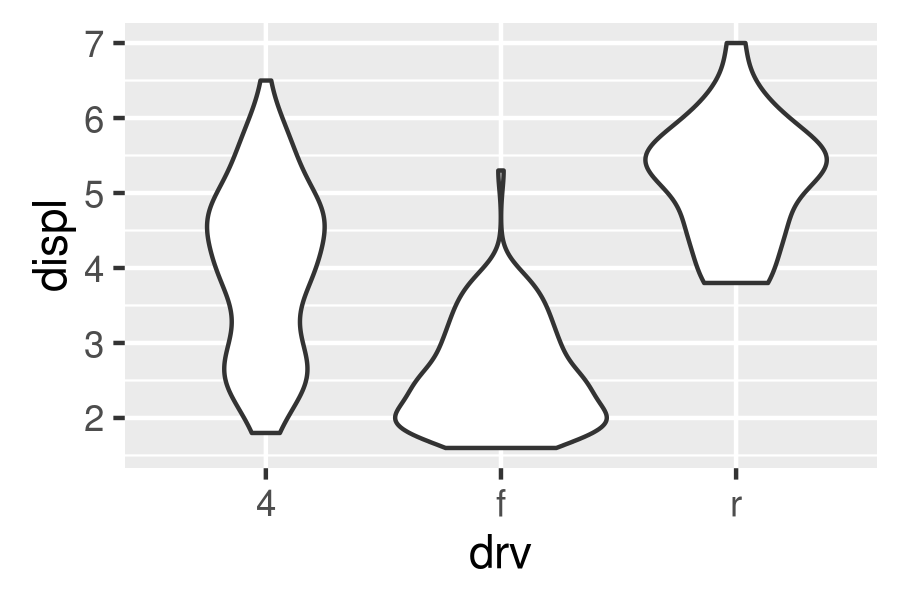

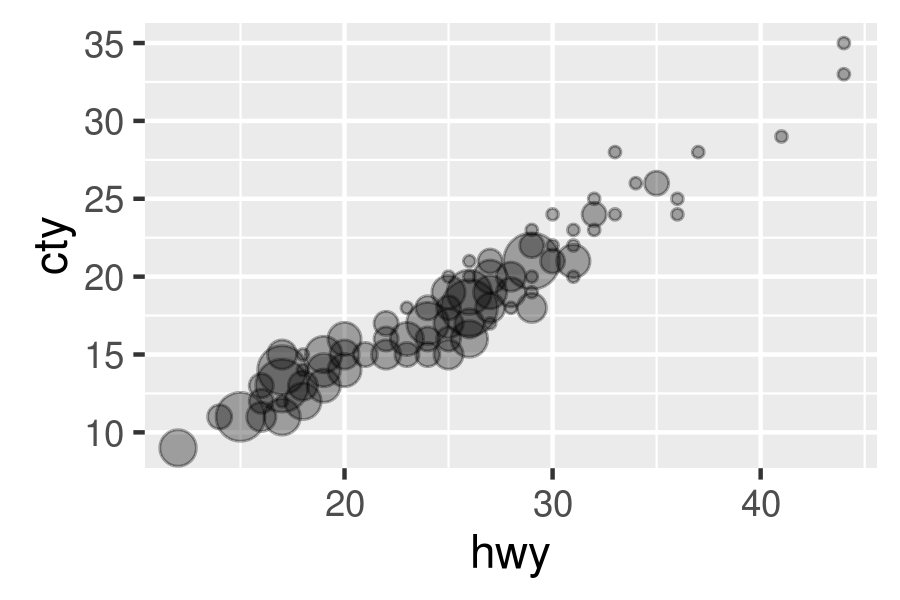

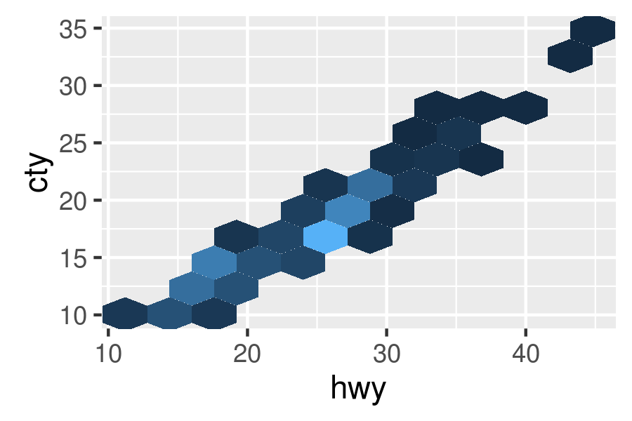

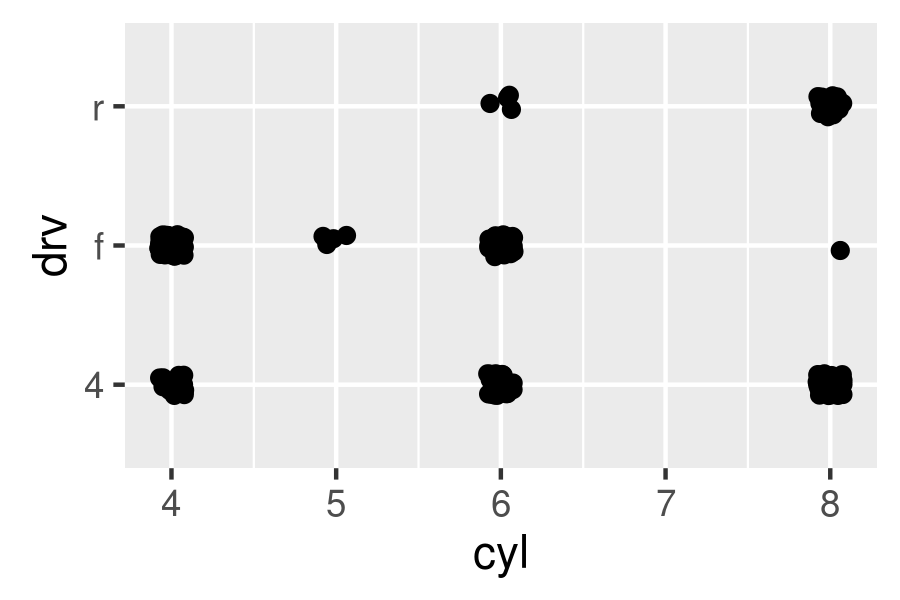

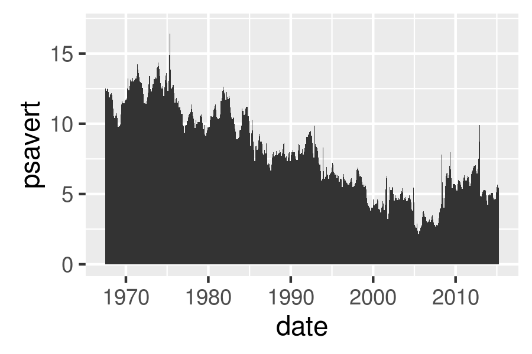

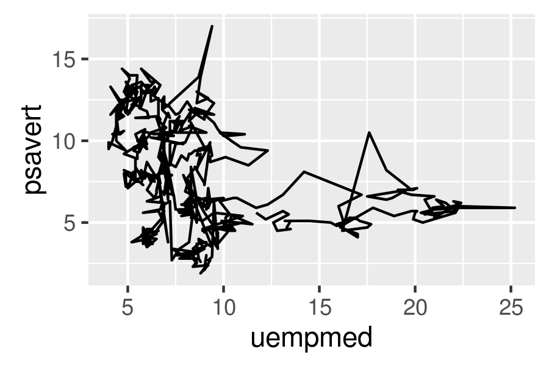

5. For each of the following problems, suggest a useful geom:
   - Display how a variable has changed over time.
   - Show the detailed distribution of a single variable.
   - Focus attention on the overall trend in a large dataset.
   - Draw a map.
   - Label outlying points.

## Stats

A statistical transformation, or **stat**, transforms the data, typically by summarising it in some manner. For example, a useful stat is the smoother, which calculates the smoothed mean of y, conditional on x. You’ve already used many of ggplot2’s stats because they’re used behind the scenes to generate many important geoms:

- `stat_bin()`: `geom_bar()`, `geom_freqpoly()`, `geom_histogram()`
- `stat_bin2d()`: `geom_bin2d()`
- `stat_bindot()`: `geom_dotplot()`
- `stat_binhex()`: `geom_hex()`
- `stat_boxplot()`: `geom_boxplot()`
- `stat_contour()`: `geom_contour()`
- `stat_quantile()`: `geom_quantile()`
- `stat_smooth()`: `geom_smooth()`
- `stat_sum()`: `geom_count()`

You’ll rarely call these functions directly, but they are useful to know about because their documentation often provides more detail about the corresponding statistical transformation.

Other stats can’t be created with a `geom_` function:

- `stat_ecdf()`: compute a empirical cumulative distribution plot.
- `stat_function()`: compute y values from a function of x values.
- `stat_summary()`: summarise y values at distinct x values.
- `stat_summary2d()`, `stat_summary_hex()`: summarise binned values.
- `stat_qq()`: perform calculations for a quantile-quantile plot.
- `stat_spoke()`: convert angle and radius to position.
- `stat_unique()`: remove duplicated rows.

There are two ways to use these functions. You can either add a `stat_()` function and override the default geom, or add a `geom_()` function and override the default stat:

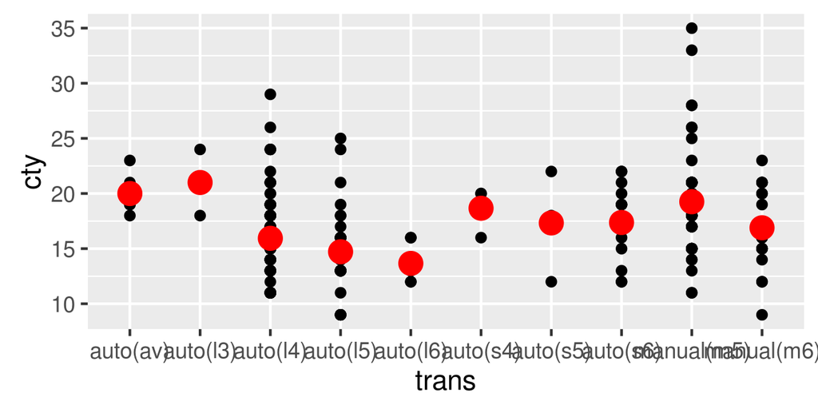

```r
ggplot(mpg, aes(trans, cty)) +
  geom_point() +
  stat_summary(geom = "point", fun.y = "mean", colour = "red", size = 4)

ggplot(mpg, aes(trans, cty)) +
  geom_point() +
  geom_point(stat = "summary", fun.y = "mean", colour = "red", size = 4)
```

I think it’s best to use the second form because it makes it more clear that you’re displaying a summary, not the raw data.

### Generated variables

Internally, a stat takes a data frame as input and returns a data frame as output, and so a stat can add new variables to the original dataset. It is possible to map aesthetics to these new variables. For example, `stat_bin`, the statistic used to make histograms, produces the following variables:

- `count`, the number of observations in each bin
- `density`, the density of observations in each bin (percentage of total / bar width)
- `x`, the centre of the bin

These generated variables can be used instead of the variables present in the original dataset. For example, the default histogram geom assigns the height of the bars to the number of observations (`count`), but if you’d prefer a more traditional histogram, you can use the density (`density`). To refer to a generated variable like density, “`..`” must surround the name. This prevents confusion in case the original dataset includes a variable with the same name as a generated variable, and it makes it clear to any later reader of the code that this variable was generated by a stat. Each statistic lists the variables that it creates in its documentation. Compare the y-axes on these two plots:

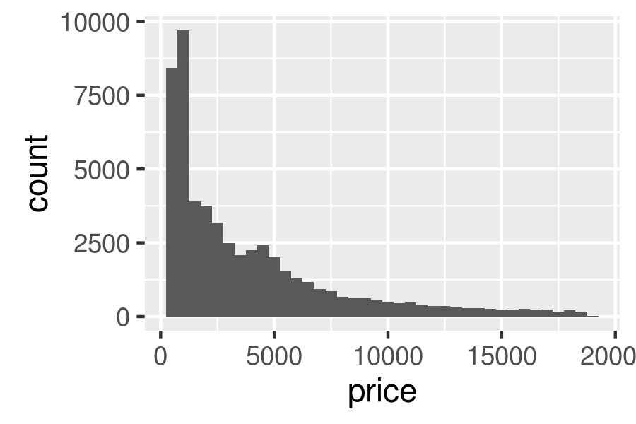

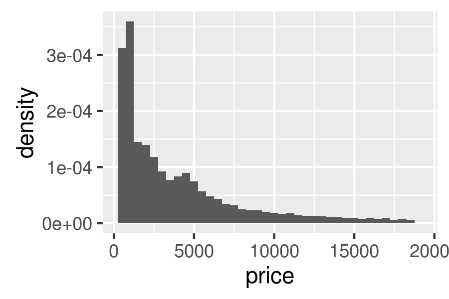

```r
ggplot(diamonds, aes(price)) +
  geom_histogram(binwidth = 500)
ggplot(diamonds, aes(price)) +
  geom_histogram(aes(y = ..density..), binwidth = 500)
```

This technique is particularly useful when you want to compare the distribution of multiple groups that have very different sizes. For example, it’s hard to compare the distribution of `price` within `cut` because some groups are quite small. It’s easier to compare if we standardise each group to take up the same area:

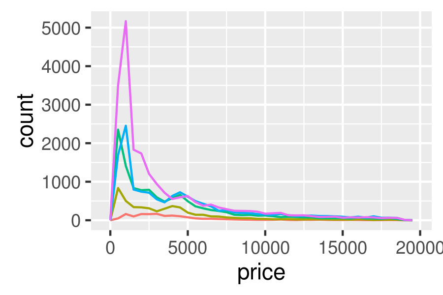

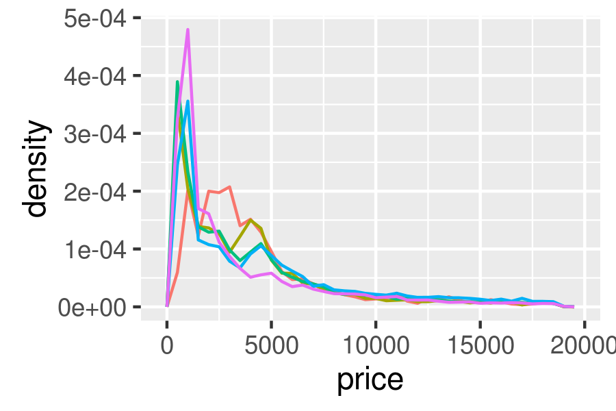

```r
ggplot(diamonds, aes(price, colour = cut)) +
  geom_freqpoly(binwidth = 500) +
  theme(legend.position = "none")

ggplot(diamonds, aes(price, colour = cut)) +
  geom_freqpoly(aes(y = ..density..), binwidth = 500) +
  theme(legend.position = "none")
```

The result of this plot is rather surprising: low quality diamonds seem to be more expensive on average. We’ll come back to this result in removing trend.

### Exercises

1. The code below creates a similar dataset to `stat_smooth()`. Use the appropriate geoms to mimic the default `geom_smooth()` display.

   ```r
   mod <- loess(hwy ~ displ, data = mpg)
   smoothed <- data.frame(displ = seq(1.6, 7, length = 50))
   pred <- predict(mod, newdata = smoothed, se = TRUE)
   smoothed$hwy <- pred$fit
   smoothed$hwy_lwr <- pred$fit - 1.96 * pred$se.fit
   smoothed$hwy_upr <- pred$fit + 1.96 * pred$se.fit
   ```

2. What stats were used to create the following plots?

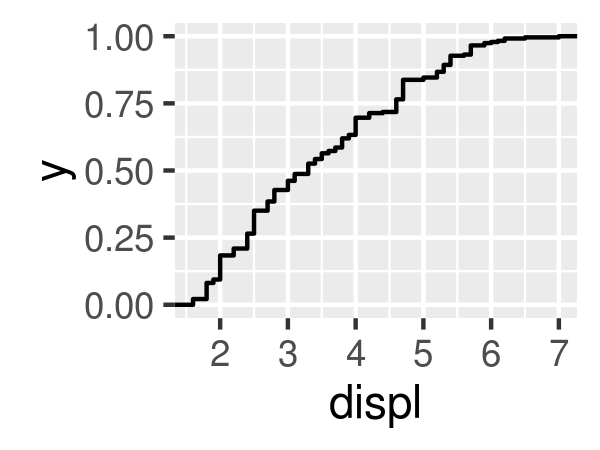

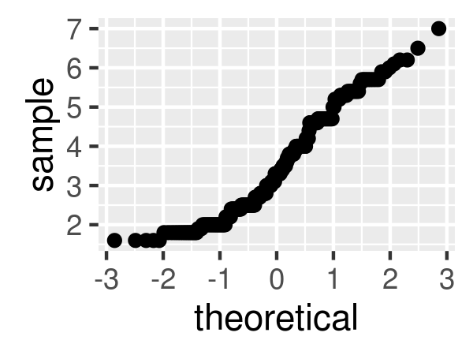

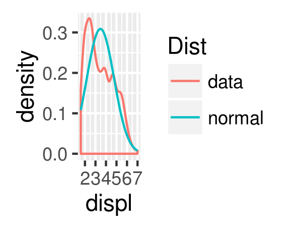

3. Read the help for `stat_sum()` then use `geom_count()` to create a plot that shows the proportion of cars that have each combination of `drv` and `trans`.

## Position adjustments

Position adjustments apply minor tweaks to the position of elements within a layer. Three adjustments apply primarily to bars:

- `position_stack()`: stack overlapping bars (or areas) on top of each other.
- `position_fill()`: stack overlapping bars, scaling so the top is always at 1.
- `position_dodge()`: place overlapping bars (or boxplots) side-by-side.

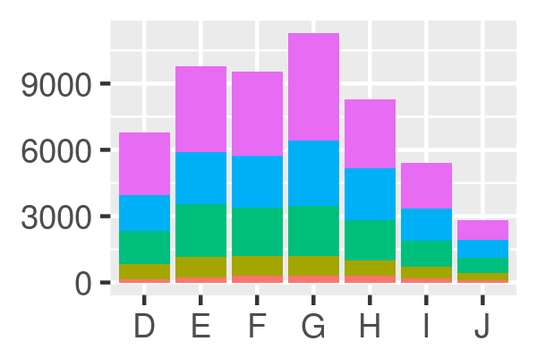

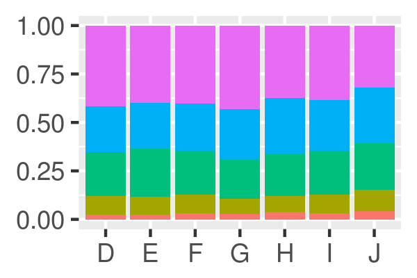

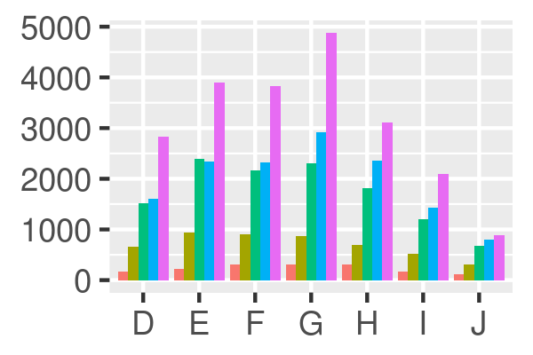

```r
dplot <- ggplot(diamonds, aes(color, fill = cut)) +
  xlab(NULL) + ylab(NULL) + theme(legend.position = "none")
# position stack is the default for bars, so `geom_bar()`
# is equivalent to `geom_bar(position = "stack")`.
dplot + geom_bar()
dplot + geom_bar(position = "fill")
dplot + geom_bar(position = "dodge")
```

There’s also a position adjustment that does nothing: `position_identity()`. The identity position adjustment isn’t useful for bars, because each bar obscures the bars behind, but there are many geoms that don’t need adjusting, like lines:

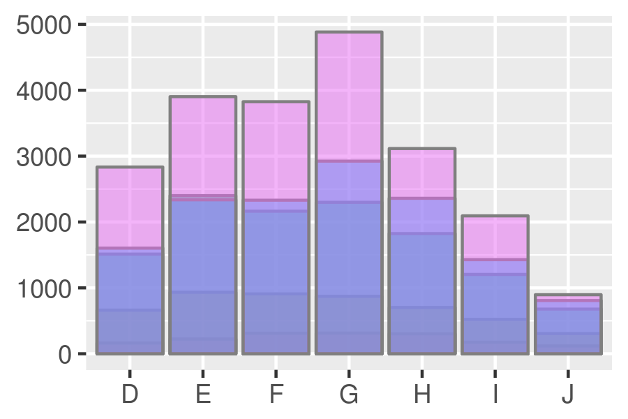

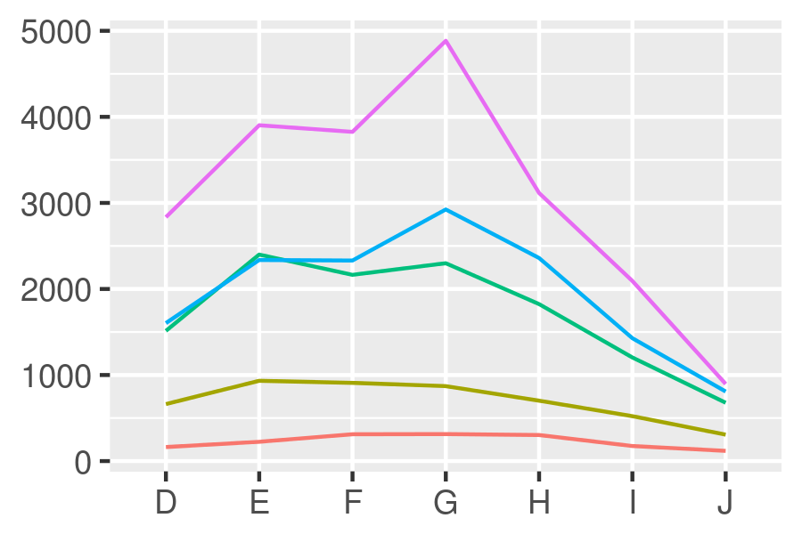

```r
dplot + geom_bar(position = "identity", alpha = 1 / 2, colour = "grey50")

ggplot(diamonds, aes(color, colour = cut)) +
  geom_line(aes(group = cut), stat = "count") +
  xlab(NULL) + ylab(NULL) +
  theme(legend.position = "none")
```

There are three position adjustments that are primarily useful for points:

- `position_nudge()`: move points by a fixed offset.
- `position_jitter()`: add a little random noise to every position.
- `position_jitterdodge()`: dodge points within groups, then add a little random noise.

Note that the way you pass parameters to position adjustments differs to stats and geoms. Instead of including additional arguments in `...`, you construct a position adjustment object, supplying additional arguments in the call:

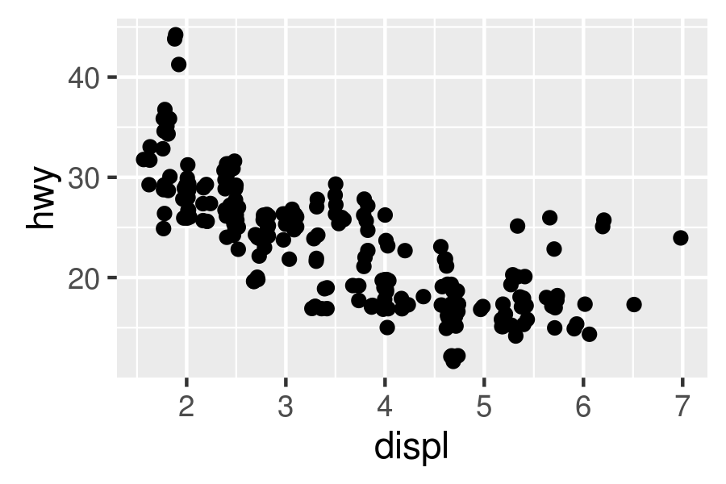

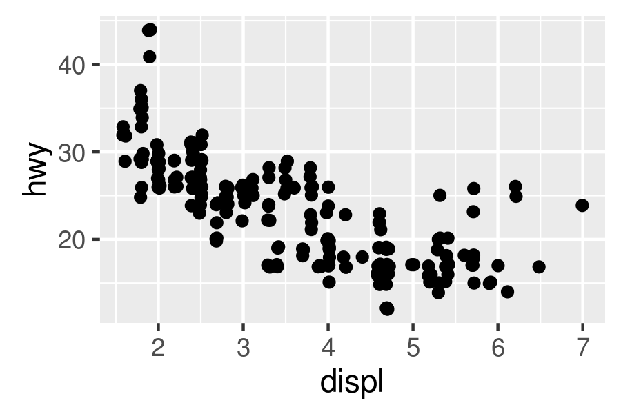

```r
ggplot(mpg, aes(displ, hwy)) +
  geom_point(position = "jitter")
ggplot(mpg, aes(displ, hwy)) +
  geom_point(position = position_jitter(width = 0.05, height = 0.5))
```

This is rather verbose, so `geom_jitter()` provides a convenient shortcut:

```r
ggplot(mpg, aes(displ, hwy)) +
  geom_jitter(width = 0.05, height = 0.5)
```

Continuous data typically doesn’t overlap exactly, and when it does (because of high data density) minor adjustments, like jittering, are often insufficient to fix the problem. For this reason, position adjustments are generally most useful for discrete data.

### Exercises

1. When might you use `position_nudge()`? Read the documentation.
2. Many position adjustments can only be used with a few geoms. For example, you can’t stack boxplots or errors bars. Why not? What properties must a geom possess in order to be stackable? What properties must it possess to be dodgeable?
3. Why might you use `geom_jitter()` instead of `geom_count()`? What are the advantages and disadvantages of each technique?
4. When might you use a stacked area plot? What are the advantages and disadvantages compared to a line plot?